# Shifting Skies: The Rise and Fall of Airlines Since 2013

Riya Saini

### Objective

In this analysis, I examine the winners and losers in air transport since 2013 using data from the Terminal Area Forecast (TAF) by the Federal Aviation Administration. I focus on airports that had more than 100,000 enplanements in 2013, identifying trends among major and minor players in the industry. Among large hubs—airports accounting for 1.00% or more of total U.S. revenue passenger enplanements—there are 31 such airports. For small hubs, which handle at least 0.05% but less than 0.25% of total U.S. revenue passenger enplanements, there are 57 airports. This study highlights which airports have grown, stagnated, or declined over time.

```r
taf_large <- read.delim(file = "TAFDetailedlarge.txt")
taf_small <- read.delim(file = "TAFDetailedsmall.txt")

# Filter on more than 100,000 enplanements
large_airports <- taf_large %>%
  filter(SYSYEAR == "2013" & T_ENPL >= 100000) %>%
  pull(LOC_ID)

taf_largefilter <- taf_large %>%
  filter(LOC_ID %in% large_airports)

small_airports <- taf_small %>%
  filter(SYSYEAR == "2013" & T_ENPL >= 100000) %>%
  pull(LOC_ID)

taf_smallfilter <- taf_small %>%
  filter(LOC_ID %in% small_airports)
```

### Large Hubs: 2013-2023

I chose to focus on civilian travel performance for each of the airports. As a result I have filtered out variables related to military, local and general aviation.One of the key criteria that demonstrates an airport’s success is the total volume of passenger movement.This metric shows how well an airport serves the passengers and ensures it’s not just a locally underutilized land use. The first plot features Total Enplanements by airports. It is the total number of revenue passengers boarding aircraft. Among large hub airports, total enplanement stands out as the most important factor.

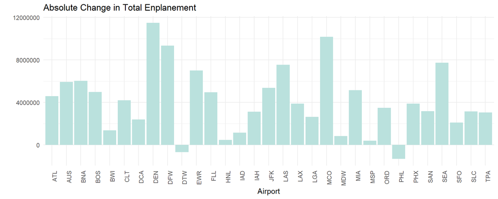

```r
changes <- taf_largefilter %>%
  filter(SYSYEAR %in% c(2013, 2023)) %>%
  group_by(LOC_ID) %>%
  summarise(
    T_ENPL_2013 = T_ENPL[SYSYEAR == 2013],
    T_ENPL_2023 = T_ENPL[SYSYEAR == 2023],
    ITN_AC_2013 = ITN_AC[SYSYEAR == 2013],
    ITN_AC_2023 = ITN_AC[SYSYEAR == 2023],
    T_ITN_2013 = T_ITN[SYSYEAR == 2013],
    T_ITN_2023 = T_ITN[SYSYEAR == 2023]
  ) %>%
  mutate(
    T_ENPL_abs_change = T_ENPL_2023 - T_ENPL_2013,
    T_ENPL_pct_change = ((T_ENPL_2023 - T_ENPL_2013) / T_ENPL_2013) * 100,
    ITN_AC_abs_change = ITN_AC_2023 - ITN_AC_2013,
    ITN_AC_pct_change = ((ITN_AC_2023 - ITN_AC_2013) / ITN_AC_2013) * 100,
    T_ITN_abs_change = T_ITN_2023 - T_ITN_2013,
    T_ITN_pct_change = ((T_ITN_2023 - T_ITN_2013) / T_ITN_2013) * 100
  ) %>%
  select(
    LOC_ID,
    T_ENPL_abs_change, T_ENPL_pct_change,
    ITN_AC_abs_change, ITN_AC_pct_change,
    T_ITN_abs_change, T_ITN_pct_change
  )

options(scipen = 999)

taf_single <- changes %>%
  select(LOC_ID, T_ENPL_abs_change)

ggplot(taf_single, aes(x = LOC_ID, y = T_ENPL_abs_change, fill = "#BAE1DD")) +
  geom_bar(stat = "identity", position = "dodge", show.legend = FALSE) +
  scale_fill_identity() +
  theme_minimal() +
  theme(axis.text.x = element_text(angle = 90, hjust = 1),
        legend.position = "none") +
  labs(title = "Absolute Change in Total Enplanement", x = "Airport", y = "")
```

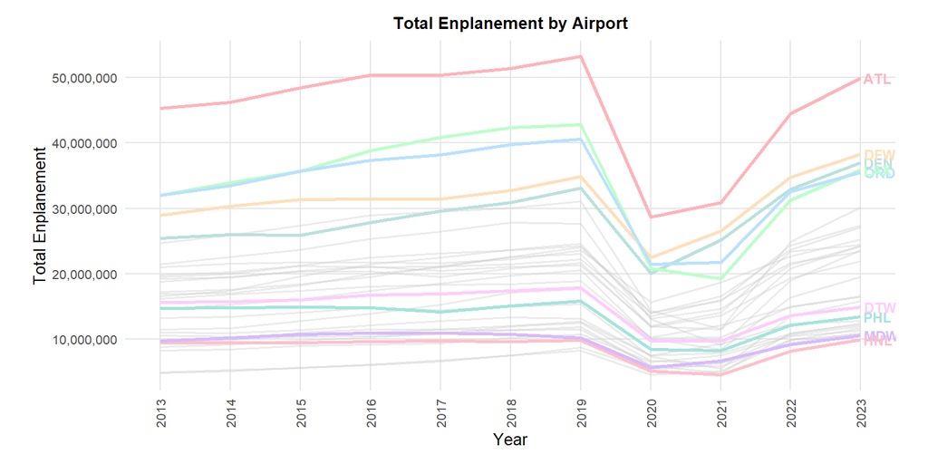

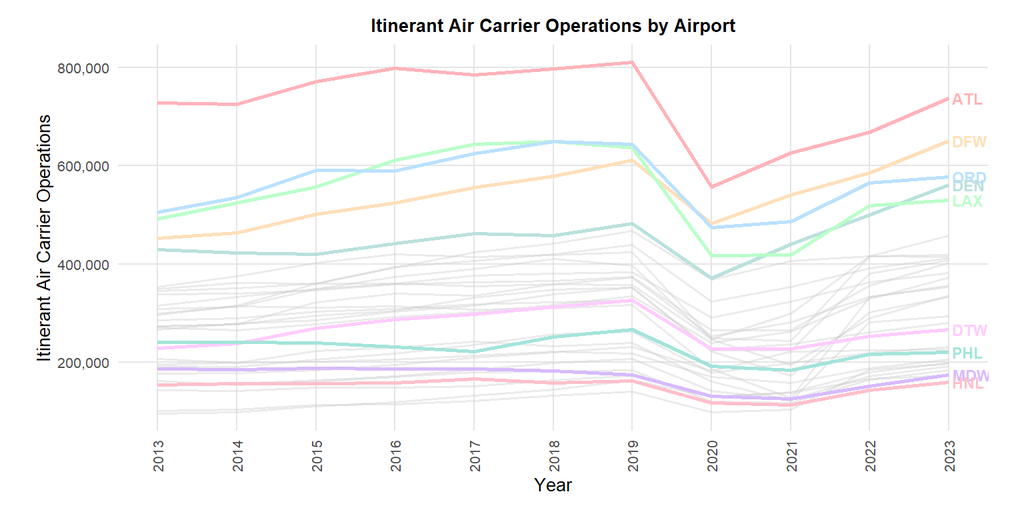

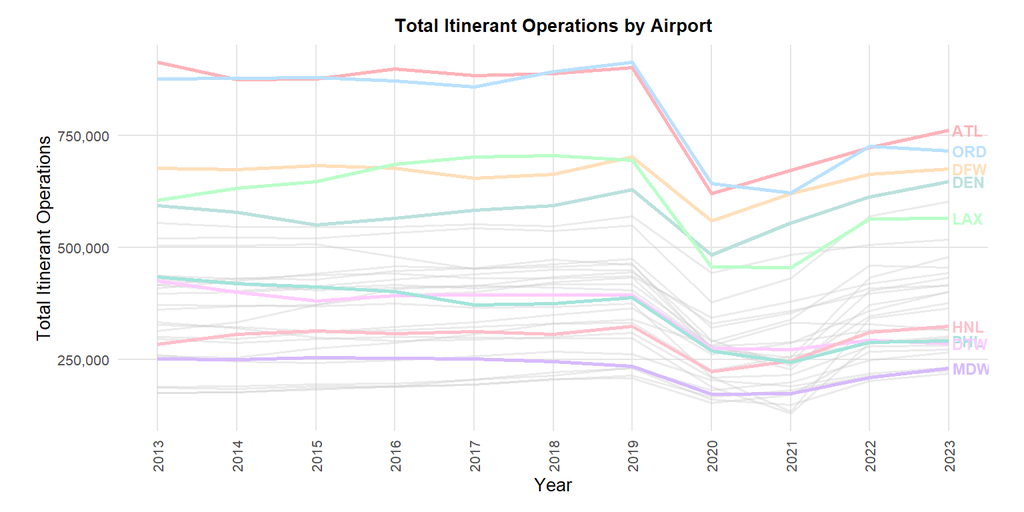

```r
columns_to_plot <- c("T_ENPL", "ITN_AC", "T_ITN")
chart_titles <- c(
  "T_ENPL" = "Total Enplanement",
  "ITN_AC" = "Itinerant Air Carrier Operations",
  "T_ITN" = "Total Itinerant Operations",
  "ITN_AT" = "Itinerant Air Taxi Operations")

highlight_airports <- c("ATL", "DFW", "DEN", "LAX", "ORD", "MDW", "HNL", "PHL", "DTW")
taf_largefilter <- taf_largefilter %>%
  mutate(LOC_ID = trimws(LOC_ID))
highlight_data <- taf_largefilter %>% filter(LOC_ID %in% highlight_airports)
pastel_colors <- c(
  "ATL" = "#FFB3BA", "DFW" = "#FFDFBA", "DEN" = "#BAE1DD",
  "LAX" = "#BAFFC9", "ORD" = "#BAE1FF", "MDW" = "#D7BAFF",
  "HNL" = "#FFC0CB", "PHL" = "#A3E4DB", "DTW" = "#FFCCFF")

for (col in columns_to_plot) {
  label_data <- taf_largefilter %>%
    group_by(LOC_ID) %>%
    filter(SYSYEAR == max(SYSYEAR)) %>%
    ungroup()

  p <- ggplot(data = taf_largefilter, aes(x = SYSYEAR, y = .data[[col]], group = LOC_ID)) +
    # Base layer:
    geom_line(color = "grey80", alpha = 0.4, size = 0.7) +
    # Overlay: Highlighted airports
    geom_line(data = highlight_data, aes(color = LOC_ID), size = 1.0) +
    theme_minimal() +
    labs(
      title = paste(chart_titles[col], "by Airport"),
      x = "Year",
      y = chart_titles[col]) +
    theme(
      axis.text.x = element_text(angle = 90, vjust = 0.5, hjust = 1, size = 8),
      axis.text.y = element_text(size = 8),
      plot.title = element_text(size = 10, face = "bold", hjust = 0.5),
      axis.title = element_text(size = 10),
      legend.position = "Right",
      legend.title = element_text(size = 8, face = "bold"),
      legend.text = element_text(size = 8),
      panel.grid.major = element_line(color = "grey90"),
      panel.grid.minor = element_blank(),
      plot.margin = margin(10, 20, 10, 20)
    ) +
    scale_y_continuous(labels = scales::comma) +
    scale_x_continuous(breaks = seq(2013, 2023, by = 1)) +
    scale_color_manual(values = pastel_colors) +
    geom_text(
      data = label_data %>% filter(LOC_ID %in% highlight_airports),
      aes(x = SYSYEAR, y = .data[[col]], label = LOC_ID, color = LOC_ID),
      hjust = -0.1,
      size = 3,
      fontface = "bold") +
    guides(color = guide_legend(title = "Highlighted Airports"))

  print(p)
}
```

From the graph, we observe a significant drop in the number of travelers during the pandemic. The Hartsfield-Jackson Atlanta International Airport (ATL) leads the pack, with substantial increases in total enplanement post-COVID. Dallas-Fort Worth International (DFW) (+9,349,097) and Denver International (DEN) (+11,498,195) overtook Los Angeles International (LAX) in total enplanement gains since 2013, followed by Chicago O’Hare International (ORD).

While enplanements remain unchanged for Chicago Midway International (MDW) and Daniel K. Inouye International (HNL), Philadelphia International (PHL) saw the largest drop in enplanement (-1,314,616), followed by Detroit Metro Wayne County (DTW) (-669,520). We see similar patterns for metrics like Itinerant Air Carrier Operations, Total Itinerant Operations.

Winners:

- Hartsfield-Jackson Atlanta International Airport (ATL)
- Denver International (DEN)

Losers:

- Philadelphia International (PHL)
- Detroit Metro Wayne County (DTW)

### Small Hubs: 2013-2023

For small hub airports, I have kept the criteria the same, except for the addition of **Total Itinerant Air Taxi Operations** as a criterion. While for large hub airports, Air Taxis make up a very small subset of revenue, therefore it was not considered, for small hub airports, air taxis can increasingly play a part in improving access for regional airports (source: [International Airport Review](https://www.internationalairportreview.com/article/231966/private-aviation-whats-in-it-for-regional-airports/)).

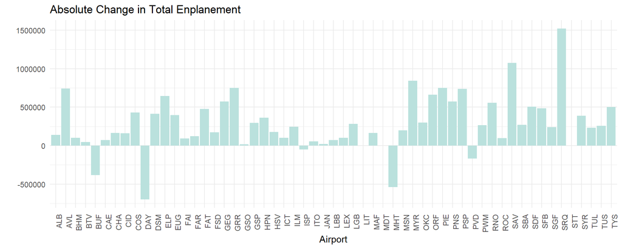

```r
changes_small <- taf_smallfilter %>%
  filter(SYSYEAR %in% c(2013, 2023)) %>%
  group_by(LOC_ID) %>%
  summarise(
    T_ENPL_2013 = T_ENPL[SYSYEAR == 2013],
    T_ENPL_2023 = T_ENPL[SYSYEAR == 2023],
    ITN_AC_2013 = ITN_AC[SYSYEAR == 2013],
    ITN_AC_2023 = ITN_AC[SYSYEAR == 2023],
    T_ITN_2013 = T_ITN[SYSYEAR == 2013],
    T_ITN_2023 = T_ITN[SYSYEAR == 2023],
    ITN_AT_2013 = ITN_AT[SYSYEAR == 2013],
    ITN_AT_2023 = ITN_AT[SYSYEAR == 2023]
  ) %>%
  mutate(
    T_ENPL_abs_change = T_ENPL_2023 - T_ENPL_2013,
    T_ENPL_pct_change = ((T_ENPL_2023 - T_ENPL_2013) / T_ENPL_2013) * 100,
    ITN_AC_abs_change = ITN_AC_2023 - ITN_AC_2013,
    ITN_AC_pct_change = ((ITN_AC_2023 - ITN_AC_2013) / ITN_AC_2013) * 100,
    T_ITN_abs_change = T_ITN_2023 - T_ITN_2013,
    T_ITN_pct_change = ((T_ITN_2023 - T_ITN_2013) / T_ITN_2013) * 100,
    ITN_AT_abs_change = ITN_AT_2023 - ITN_AT_2013,
    ITN_AT_pct_change = ((ITN_AT_2023 - ITN_AT_2013) / ITN_AT_2013) * 100
  ) %>%
  select(
    LOC_ID,
    T_ENPL_abs_change, T_ENPL_pct_change,
    ITN_AC_abs_change, ITN_AC_pct_change,
    T_ITN_abs_change, T_ITN_pct_change,
    ITN_AT_abs_change, ITN_AT_pct_change
  )

options(scipen = 999)

taf_single <- changes_small %>%
  select(LOC_ID, T_ENPL_abs_change)

ggplot(taf_single, aes(x = LOC_ID, y = T_ENPL_abs_change, fill = "#BAE1DD")) +
  geom_bar(stat = "identity", position = "dodge", show.legend = FALSE) +
  scale_fill_identity() +
  theme_minimal() +
  theme(axis.text.x = element_text(angle = 90, hjust = 1),
        legend.position = "none") +
  labs(title = "Absolute Change in Total Enplanement", x = "Airport", y = "")
```

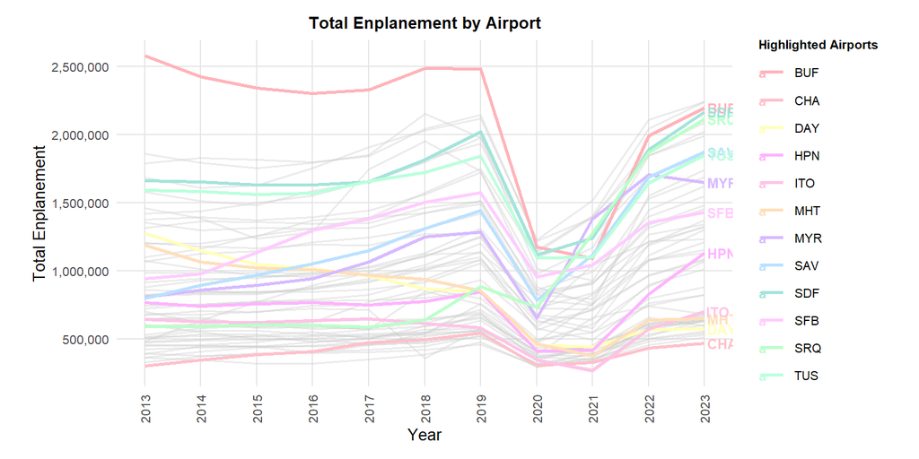

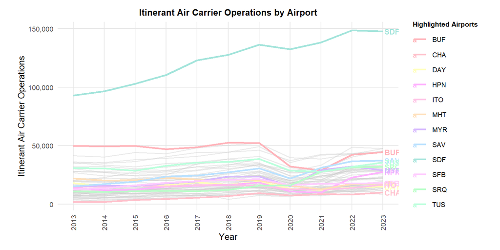

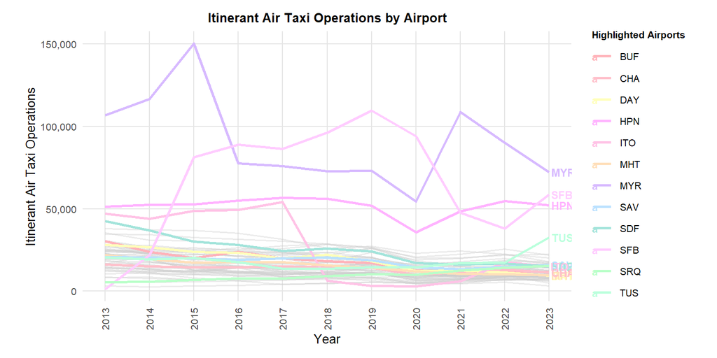

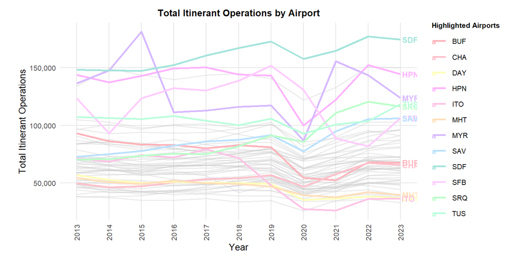

```r
columns_to_plot <- c("T_ENPL", "ITN_AC", "ITN_AT", "T_ITN")
highlight_airports2 <- c("BUF", "MHT", "DAY", "SRQ", "SAV", "MYR", "CHA", "SDF", "SFB", "HPN", "TUS", "ITO")
taf_smallfilter <- taf_smallfilter %>%
  mutate(LOC_ID = trimws(LOC_ID))
highlight_data2 <- taf_smallfilter %>% filter(LOC_ID %in% highlight_airports2)
pastel_colors2 <- c(
  "BUF" = "#FFB3BA", "MHT" = "#FFDFBA", "DAY" = "#FFFFBA",
  "SRQ" = "#BAFFC9", "SAV" = "#BAE1FF", "MYR" = "#D7BAFF",
  "CHA" = "#FFC0CB", "SDF" = "#A3E4DB", "SFB" = "#FFCCFF",
  "HPN" = "#FFB3FF", "TUS" = "#BAFFDC", "ITO" = "#FFC3E6")

for (col in columns_to_plot) {
  label_data <- taf_smallfilter %>%
    group_by(LOC_ID) %>%
    filter(SYSYEAR == max(SYSYEAR)) %>%
    ungroup()

  p <- ggplot(data = taf_smallfilter, aes(x = SYSYEAR, y = .data[[col]], group = LOC_ID)) +
    # Base layer
    geom_line(color = "grey80", alpha = 0.4, size = 0.7) +
    # Overlay
    geom_line(data = highlight_data2, aes(color = LOC_ID), size = 1.0) +
    theme_minimal() +
    labs(
      title = paste(chart_titles[col], "by Airport"),
      x = "Year",
      y = chart_titles[col]) +
    theme(
      axis.text.x = element_text(angle = 90, vjust = 0.5, hjust = 1, size = 8),
      axis.text.y = element_text(size = 8),
      plot.title = element_text(size = 10, face = "bold", hjust = 0.5),
      axis.title = element_text(size = 10),
      legend.position = "right",
      legend.title = element_text(size = 8, face = "bold"),
      legend.text = element_text(size = 8),
      panel.grid.major = element_line(color = "grey90"),
      panel.grid.minor = element_blank(),
      plot.margin = margin(10, 20, 10, 20)
    ) +
    scale_y_continuous(labels = scales::comma) +
    scale_x_continuous(breaks = seq(2013, 2023, by = 1)) +
    scale_color_manual(values = pastel_colors2) +
    geom_text(
      data = label_data %>% filter(LOC_ID %in% highlight_airports2),
      aes(x = SYSYEAR, y = .data[[col]], label = LOC_ID, color = LOC_ID),
      hjust = -0.1,
      size = 3,
      fontface = "bold") +
    guides(color = guide_legend(title = "Highlighted Airports"))

  print(p)
}
```

Small hub airports, which account for 0.05% to 0.25% of total U.S. revenue passenger enplanements. From the plot of total enplanements, it is evident that despite a stark drop in passengers, Buffalo Niagara International (BUF) still ranks among the highest in total enplanements. Manchester Boston Regional (MHT) and James M. Cox Dayton International (DAY) experienced significant declines of 45% and 55% in enplanements, respectively.

In contrast, Sarasota/Bradenton International (SRQ), Savannah/Hilton Head International (SAV), and Myrtle Beach International (MYR) saw the highest absolute increases in enplanements over the decade, each exceeding a 100% increase. While several other airports also doubled their passenger numbers, the average higher number of passengers makes some airports clear winners in terms of revenue. Overall, Lovell Field in Chattanooga (CHA) ranks at the bottom.

Unlike large hubs, where high passenger movement often correlates with high aircraft operations, small hubs show more variation. For instance, in itinerant air carrier operations, Louisville Muhammad Ali International Airport (SDF) outperforms all other airports significantly. SAV and SRQ also saw more than a 150% increase in air carrier operations, whereas BUF and MHT experienced declines of 11% and 20%, respectively.

Based on this discussion, we have the following results for small hub airports:

Winners:

- Sarasota/Bradenton International (SRQ)
- Savannah/Hilton Head International (SAV)
- Louisville Muhammad Ali International (SDF)

To wrap up, I see total passenger movement as the most critical metric for assessing airport performance, especially for large hubs where it aligns closely with other operational measures. For small hubs, this relationship isn’t as straightforward. Airports with a focus on military operations or large based fleets weren’t included in this analysis since my focus is on passenger traffic and revenue.

### Airport Delays

For the second part, I wanted to look at the trends between 2013 and 2023 for the busiest month of the year: July. Arrival and departure delays are critical indicators of an airport’s operational efficiency. Delays can significantly affect flight scheduling, leading to cascading effects throughout the day. For air carriers, higher delays can result in financial consequences, including increased fuel costs, missed flight slots, and additional operational expenses. Moreover, airports may impose penalties or higher fees on airlines based on their delay performance, which can impact the carriers’ profitability. Based on the average arrival and departure delay plots for 2013 and 2023, we observe the following trends for the selected airports:

For the majority of the selected airports, there is a clear upward trend in both arrival and departure delays from 2013 to 2023. The increase in delays suggests a growing congestion issue, system inefficiencies, or other operational challenges faced by these airports over the past decade.Hartsfield-Jackson Atlanta International Airport (ATL) stands out as the only airport where both arrival and departure delays have decreased from 2013 to 2023.For a large hub airport, delays at Philadelphia International Airport have increased over 10 minutes, exceeding 30 minutes in total delay.

```r
dat13 <- read.csv(file = "T_ONTIME_REPORTING_2013.csv")
dat23 <- read.csv(file = "T_ONTIME_REPORTING_2023.csv")

# selected airports
selected_airports <- c("ATL", "DEN", "PHL", "DTW", "SRQ", "SAV", "SDF", "BUF", "MHT")

# Filter for 2013
filtered_dat13 <- dat13 %>%
  filter(ORIGIN %in% selected_airports | DEST %in% selected_airports)
filtered_dat13 <- filtered_dat13 %>%
  mutate(
    Selected_Airport = case_when(
      ORIGIN %in% selected_airports ~ ORIGIN,
      DEST %in% selected_airports ~ DEST,
      TRUE ~ NA_character_)) %>%
  select(DAY_OF_WEEK, ARR_DELAY_NEW, DEP_DELAY_NEW, CANCELLED, DIVERTED,Selected_Airport)

# Filter for 2023
filtered_dat23 <- dat23 %>%
  filter(ORIGIN %in% selected_airports | DEST %in% selected_airports)
filtered_dat23 <- filtered_dat23 %>%
  mutate(
    Selected_Airport = case_when(
      ORIGIN %in% selected_airports ~ ORIGIN,
      DEST %in% selected_airports ~ DEST,
      TRUE ~ NA_character_)) %>%
  select(DAY_OF_WEEK, ARR_DELAY_NEW, DEP_DELAY_NEW, CANCELLED, DIVERTED,Selected_Airport)

# Combine data for 2013 and 2023
combined_data <- bind_rows(
  filtered_dat13 %>%
    mutate(Year = 2013),
  filtered_dat23 %>%
    mutate(Year = 2023))
```

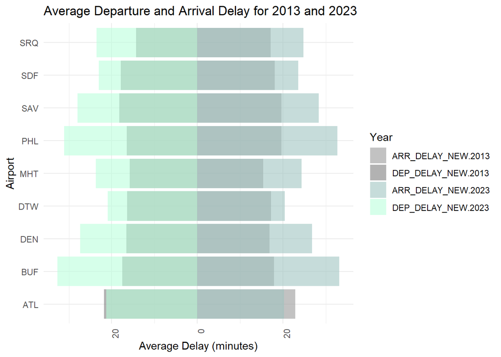

```r
# Plot for Arrival and Departure Delays (Bidirectional Bar Chart)
combined_data_long <- combined_data %>%
  pivot_longer(cols = c("ARR_DELAY_NEW", "DEP_DELAY_NEW"),
               names_to = "Delay_Type",
               values_to = "Delay") %>%
  mutate(Delay = if_else(Delay_Type == "DEP_DELAY_NEW", -Delay, Delay))

# plot
bidirectional_plot <- ggplot(combined_data_long, aes(x = Selected_Airport, y = Delay, fill = interaction(Delay_Type, Year))) +
  geom_bar(stat = "summary", fun = "mean", position = "identity", alpha = 0.6, size = 0.5) +
  labs(title = "Average Departure and Arrival Delay for 2013 and 2023",
       x = "Airport",
       y = "Average Delay (minutes)",
       fill = "Year") +
  scale_y_continuous(labels = abs) +
  scale_fill_manual(values = c("ARR_DELAY_NEW.2013" = "grey60",
                               "DEP_DELAY_NEW.2013" = "grey50",
                               "ARR_DELAY_NEW.2023" = "#A0C4C1",
                               "DEP_DELAY_NEW.2023" = "#BAFFDC")) +
  theme_minimal() +
  theme(axis.text.x = element_text(angle = 90, hjust = 1))+
  coord_flip()

print(bidirectional_plot)
```

Flight cancellations and diversions also provide critical insights into the operational efficiency. Cancellations can reflect issues such as weather disruptions, staffing shortages, or logistical bottlenecks, while flight diversions typically indicate capacity constraints or unforeseen emergencies, like bad weather at the destination. By examining these metrics, we gain a deeper understanding of how airports cope with disruptions and their ability to maintain smooth operations. The data shows a clear trend of increasing flight cancellations over the past decade, with Buffalo (BUF) having the largest share of cancelled flights in 2023. On the flip side, flight diversions have generally decreased, especially at SRQ, which previously had the highest diversion rate. However, airports like Denver (DEN) and Manchester (MHT) have seen an increase in diversions.

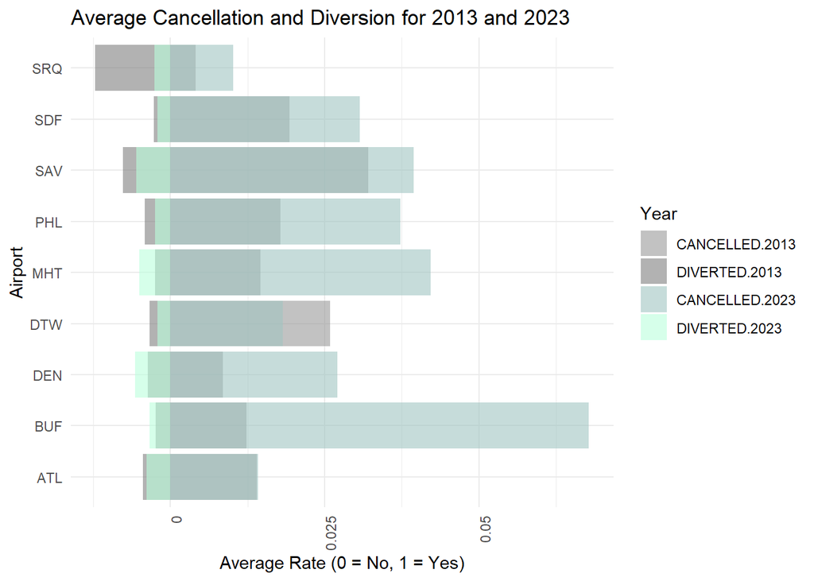

```r
# Create the long format dataset for CANCELLED and DIVERTED delay types
combined_data_long_cd <- combined_data %>%
  pivot_longer(cols = c("CANCELLED", "DIVERTED"),
               names_to = "Delay_Type",
               values_to = "Delay") %>%
  mutate(Delay = if_else(Delay_Type == "DIVERTED", -Delay, Delay))

# Create the plot for CANCELLED and DIVERTED
bidirectional_plot_cd <- ggplot(combined_data_long_cd, aes(x = Selected_Airport, y = Delay, fill = interaction(Delay_Type, Year))) +
  geom_bar(stat = "summary", fun = "mean", position = "identity", alpha = 0.6, size = 0.5) +
  labs(title = "Average Cancellation and Diversion for 2013 and 2023",
       x = "Airport",
       y = "Average Rate (0 = No, 1 = Yes)",
       fill = "Year") +
  scale_y_continuous(labels = abs) +
  scale_fill_manual(values = c("CANCELLED.2013" = "grey60",
                               "DIVERTED.2013" = "grey50",
                               "CANCELLED.2023" = "#A0C4C1",
                               "DIVERTED.2023" = "#BAFFDC")) +
  theme_minimal() +
  theme(axis.text.x = element_text(angle = 90, hjust = 1)) +
  coord_flip()

# Display the plot
print(bidirectional_plot_cd)
```

When evaluating the airports based on total passenger movement (such as total enplanements, itinerant operations, and airport operations), airports with higher traffic like ATL ranked the highest in terms of total passenger movements. The results from the delay plots align somewhat with this, where ATL remains a top performer despite higher traffic, whereas other airports with significant traffic, such as DEN, PHL and DTW, show increased delays. Additionally, while small hub airports like Buffalo and Louisville may serve fewer passengers, the trend of increased delays suggests their operational systems might not be as optimized as larger airports like ATL or ORD.